Modeling the Future Challenge: Cause of Death

Libraries Needed:

```r
library(tidyverse)
library(ggplot2)
library(knitr)
library(dplyr)
```

Reading in the data

```r
data <- read_csv("data/deaths.csv")
```

A brief look at the data set

```r
knitr::kable(head(data), format="markdown")
```

| Year | Cause of Death | State | Deaths |
| --- | --- | --- | --- |
| 1999 | Accidents (unintentional injuries) (V01-X59,Y85-Y86) | Alabama | 3292 |
| 1999 | Accidents (unintentional injuries) (V01-X59,Y85-Y86) | Alaska | 362 |
| 1999 | Accidents (unintentional injuries) (V01-X59,Y85-Y86) | Arizona | 3910 |
| 1999 | Accidents (unintentional injuries) (V01-X59,Y85-Y86) | Arkansas | 2006 |
| 1999 | Accidents (unintentional injuries) (V01-X59,Y85-Y86) | California | 16672 |
| 1999 | Accidents (unintentional injuries) (V01-X59,Y85-Y86) | Colorado | 2984 |

Cleaning up the data

```r
data = data %>% rename(Cause = `Cause of Death`)
data$Cause = as.factor(data$Cause)
data$State = as.factor(data$State)
summary(data)
```

```
##       Year                                                       Cause
##  Min.   :1999   Accidents (unintentional injuries) (V01-X59,Y85-Y86): 1122
##  1st Qu.:2004   Alzheimer's disease (G30)                           : 1122
##  Median :2010   Cerebrovascular diseases (I60-I69)                  : 1122
##  Mean   :2010   Chronic lower respiratory diseases (J40-J47)        : 1122
##  3rd Qu.:2015   Diseases of heart (I00-I09,I11,I13,I20-I51)         : 1122
##  Max.   :2020   Influenza and pneumonia (J09-J18)                   : 1122
##                 (Other)                                             :24376
##           State           Deaths
##  California  :  730   Min.   :    10
##  Texas       :  713   1st Qu.:    61
##  Florida     :  706   Median :   296
##  New York    :  687   Mean   :  2775
##  Pennsylvania:  687   3rd Qu.:  1626
##  Ohio        :  685   Max.   :163400
##  (Other)     :26900
```

## 1.

### Describe in a few sentences two different groups, industries, sectors, or other areas of society that would experience a loss due to an increase in mortality rate in the United States.

The agriculture industry would experience a loss due to their being fewer people in the workforce to grow food. A decrease in the availability of food would affect everybody. The United States Department of Defense relies on a very large workforce to function; with increasing mortality rates, their industry will suffer.

## 2.

### Describe in no more than a few sentences an example of how insurance may be used to help mitigate or manage the losses you noted in question 1.

Insurance such as health insurance would be able to better provide treatment to people in those industries to get them the aid they need to survive. As mental health problems are increasing alongside physical health issues, health insurance to cover treatment for both would be most effective.

## 3.

### Describe in no more than a few sentences an example of how implementing new policies, procedures, or systems to help change behaviors of those involved to help mitigate or manage the losses you noted in this scenario.

Teaching better information and increasing awareness about mental health would decrease mortality rates from suicides. Greater availability for drug treatments and education about drugs would decrease the mortality from opioids.

## 4.

### Describe in no more than a few sentences an example of how those involved in the scenario may be able to help modify the possible outcomes to help mitigate or manage the losses you noted.

The think tank in the scenario could advocate for greater suicide or drug related death prevention to change government policies.

# Part 2: Data Identification and Analysis

## 5.

### Based on the five categories outlined in the Actuarial Process Guide, what category (or categories) do you classify the attached dataset into? Provide a rationale for your reasoning.

The attached dataset falls into defining historical trends as well as projecting future trends. The dataset provides precise records of all deaths in all states by year, this historical information may also be used to predict amounts of deaths in the future. The dataset does not include the type of person most likely to suffer any of the outcomes, nor does it say how much each death costs We also do not know how many of the people who die use insurance or how likely they are to benefit from death prevention measures; as such we cannot define the dataset as separating potential outcomes, defining severity of potential losses, or defining frequency of potential outcomes.

## 6.

### Based on your answer to the previous question, identify one limitation there is on the types of questions or analysis that you can perform on the data?

Without knowing any insurance information, we cannot determine the expected cost of any deaths.

## 7.

### Beyond the data provided in the attached spreadsheet, identify one other type of data or piece of information that could be valuable in analyzing the risks associated with evaluating cause of death and evaluation of impact of policy programs?

Knowing information about any preventive measures enacted in any states that may have lowered the death rates would be beneficial for determining the most effective way of preventing death.

## 8.

### The researcher compiling this dataset compared select causes of death after pulling the raw data to the numbers from the last dataset published from the CDC for 1999-2017. The researcher compared the raw data to the last published dataset to check and see if any cleaning was needed. Use the table below to answer the following questions.

| selected_causes_of_death | last_published | raw_data |
| --- | --- | --- |
| Accidents (unintentional injuries) | 4695640 | 2460168 |
| All Causes | 95457138 | 117336580 |
| Alzheimer’s disease | 2989632 | 1710456 |
| Cerebrovascular diseases | 5453046 | 2681047 |
| Chronic lower respiratory diseases | 5189854 | 2811355 |
| Diabetes Mellitus | 2799886 | 1312394 |
| Diseases of heart | 24445280 | 12230857 |
| Influenza and pneumonia | 2189282 | 1089286 |
| Intentional self-harm (suicide) | 1394032 | 753901 |
| Malignant neoplasms | 21687288 | 10817779 |
| Nephritis, nephrotic syndrome and nephrosis | 1717226 | 797232 |

### Based on this information, what might have indicated to the researcher in this comparison of the 1999-2017 Last Published dataset and the 1999-2020 Raw Dataset that cleaning of the data was needed?

The data in the raw dataset and the published data differ significantly in all sections, in some cases the raw data shows significantly higher numbers and in others it shows lower numbers compared to the published data.

Part 2

# Part 3: Mathematical Modeling

## 9.

### The information in the Scenario Introduction describes the % annual reduction in mortality expected for each Of the programs listed - this is an assumption made to simplify the modeling process. How and why might this assumption limit the realism Of modeling and forecasting future impact Of the programs? Describe one way in which easing or revisiting this assumption could lead to an interesting and useful analysis in future years.

Such an assumption is unknown to be a realistic expectation for death prevention, a measure may cause an 8% reduction in one year but in the consecutive years it may be different. It may be interesting to inspect how having a program for many consecutive years affects its effectiveness.

## 10.

What are the ten leading causes Of death in the US identified in the data from 1999 to 2020 based on average number of deaths per year? Rank the causes in your response and include the totals.

```r
head(data %>% group_by(Cause) %>% summarize(total = sum(Deaths)/22) %>% arrange(desc(total)), n=10)
```

```
## # A tibble: 10 × 2
##    Cause                                                                   total
##    <fct>                                                                   <dbl>
##  1 Diseases of heart (I00-I09,I11,I13,I20-I51)                            1.31e6
##  2 Malignant neoplasms (C00-C97)                                          1.05e6
##  3 Accidents (unintentional injuries) (V01-X59,Y85-Y86)                   2.64e5
##  4 Chronic lower respiratory diseases (J40-J47)                           2.55e5
##  5 Cerebrovascular diseases (I60-I69)                                     2.43e5
##  6 Influenza and pneumonia (J09-J18)                                      1.44e5
##  7 Alzheimer's disease (G30)                                              1.00e5
##  8 Nephritis, nephrotic syndrome and nephrosis (N00-N07,N17-N19,N25-N27)  7.31e4
##  9 Transport accidents (V01-V99,Y85)                                      7.15e4
## 10 Intentional self-harm (suicide) (*U03,X60-X84,Y87.0)                   6.85e4
```

## 11.

Do any Of the top ten leading causes Of death change when considering total deaths from 1999 to 2020 instead Of average number of deaths? Explain and justify your answer.

```r
head(data %>% group_by(Cause) %>% summarize(total = sum(Deaths)) %>% arrange(desc(total)), n=10)
```

```
## # A tibble: 10 × 2
##    Cause                                                                   total
##    <fct>                                                                   <dbl>
##  1 Diseases of heart (I00-I09,I11,I13,I20-I51)                            2.88e7
##  2 Malignant neoplasms (C00-C97)                                          2.30e7
##  3 Accidents (unintentional injuries) (V01-X59,Y85-Y86)                   5.80e6
##  4 Chronic lower respiratory diseases (J40-J47)                           5.62e6
##  5 Cerebrovascular diseases (I60-I69)                                     5.36e6
##  6 Influenza and pneumonia (J09-J18)                                      3.16e6
##  7 Alzheimer's disease (G30)                                              2.20e6
##  8 Nephritis, nephrotic syndrome and nephrosis (N00-N07,N17-N19,N25-N27)  1.61e6
##  9 Transport accidents (V01-V99,Y85)                                      1.57e6
## 10 Intentional self-harm (suicide) (*U03,X60-X84,Y87.0)                   1.51e6
```

None of the leading causes of death change when comparing the average over 22 years and the total. Since each number is changed equally to take the average, the order does not change.

## 12.

If you choose a person at random from among those who died in 2015, what is the probability he/she has “Influenza and Pneumonia” indicated as the cause Of death?

```r
deaths = sum(data %>% filter(Year == "2015" & Cause == "Influenza and pneumonia (J09-J18)") %>% select(Deaths))
totalDeaths = sum(data %>% filter(Year == "2015") %>% select(Deaths))
prob = deaths/totalDeaths
```

[output not shown]

## 13.

If you randomly select a person from New York who died of chronic lower respiratory diseases, in which year was it most likely that he/she died? What is the probability the person died in that year? Explain.

```r
data %>% group_by(Year) %>% filter(State == "New York" & Cause == "Chronic lower respiratory diseases (J40-J47)") %>% select(Deaths) %>% arrange(desc(Deaths))
```

```
## # A tibble: 22 × 2
## # Groups:   Year [22]
##     Year Deaths
##    <dbl>  <dbl>
##  1  1999  12866
##  2  2017  12864
##  3  2018  12806
##  4  2002  12688
##  5  2015  12680
##  6  2012  12576
##  7  2013  12556
##  8  2001  12482
##  9  2008  12474
## 10  2011  12428
## # … with 12 more rows
```

The most likely year of death is 1999

```r
deaths = sum(data %>% filter(Year == "1999" & State == "New York" & Cause == "Chronic lower respiratory diseases (J40-J47)") %>% select(Deaths))
totalDeaths = sum(data %>% filter(State == "New York" & Cause == "Chronic lower respiratory diseases (J40-J47)") %>% select(Deaths))
prob = deaths/totalDeaths
```

The probability of dying in 1999 if the cause of death is chronic lower respiratory diseases and the state is New York is 0.0474582.

## 14.

What is the chance that the cause of death was cancer (ie, malignant neoplasm) for a randomly selected individual in the U.S. from 1999-2020?

```r
deaths = sum(data %>% filter(Cause == "Malignant neoplasms (C00-C97)") %>% select(Deaths))
totalDeaths = sum(data %>% select(Deaths))
prob = deaths/totalDeaths
```

The probability of having died of cancer is 0.2663998.

## 15.

The average cost for end-of-life medical care for a cancer patient in the U.S. is $105,500. What is the expected value of loss in medical costs for an individual who dies of cancer?

$105,500

## 16.

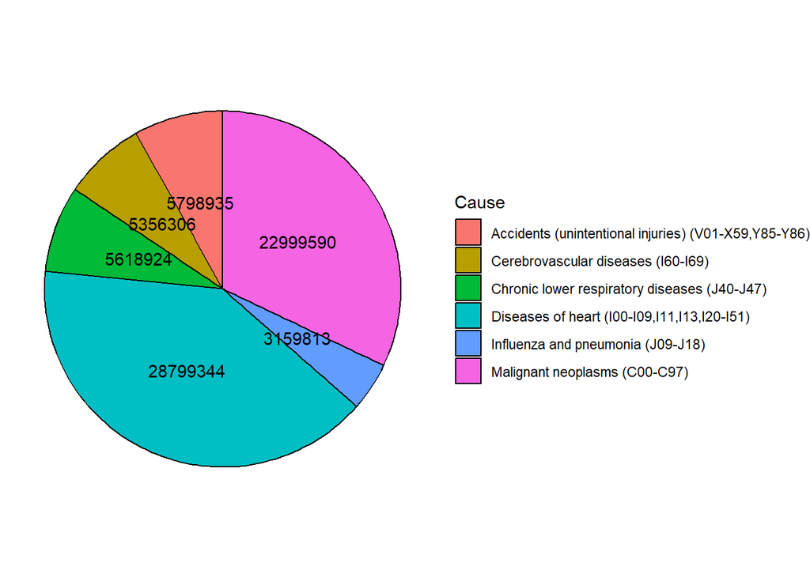

```r
topDeaths = head(data %>% group_by(Cause) %>% summarize(total = sum(Deaths)) %>% arrange(desc(total)), n=6)
ggplot(data = topDeaths, aes(x="", y=total, fill=Cause)) +
  geom_col(width = 1, color="black") +
  coord_polar("y", start=0) +
  theme_void() +
  geom_text(aes(label = total), position = position_stack(vjust = 0.5))
```

## 17.

Create a scatter plot or line graph that charts each of the top 10 causes of death over the 1999-2020 time period (total sum of deaths, not average deaths). Offer two observations from the chart about the trends in causes of death.

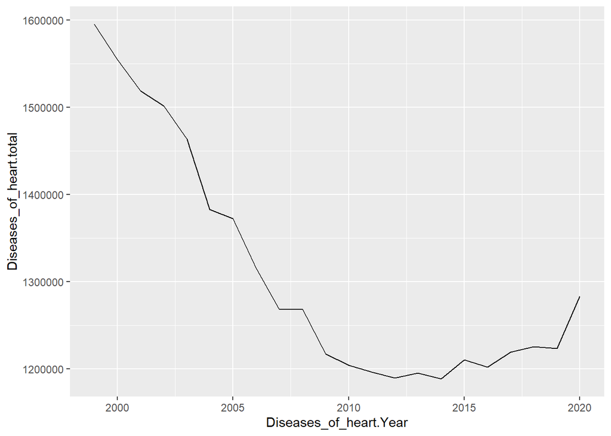

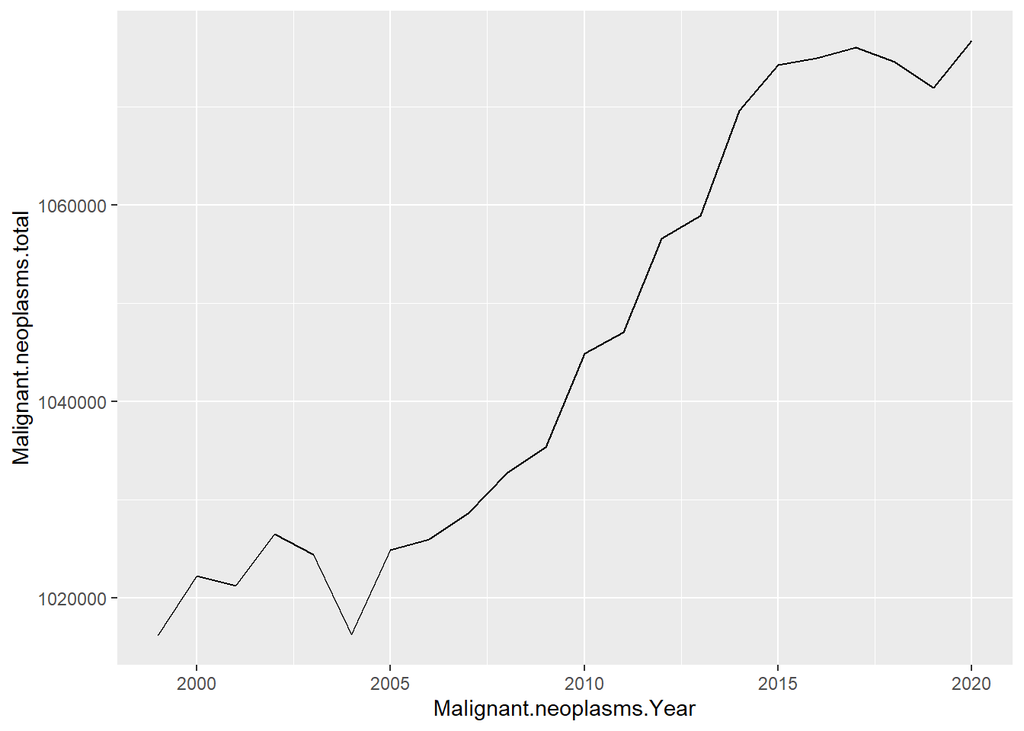

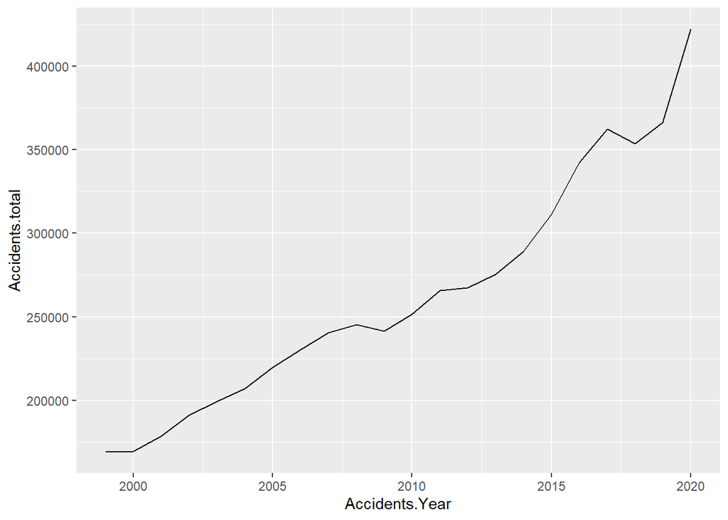

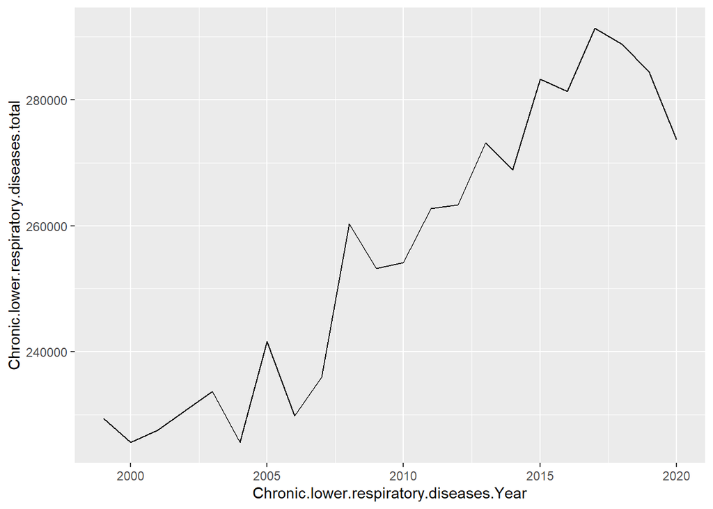

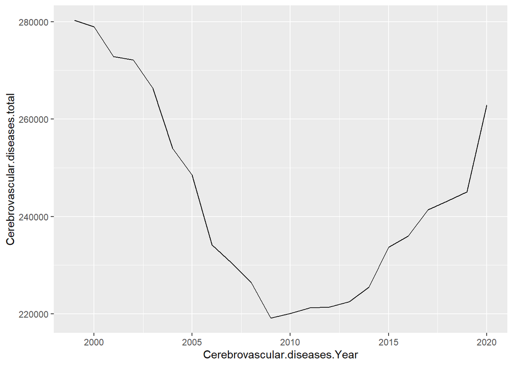

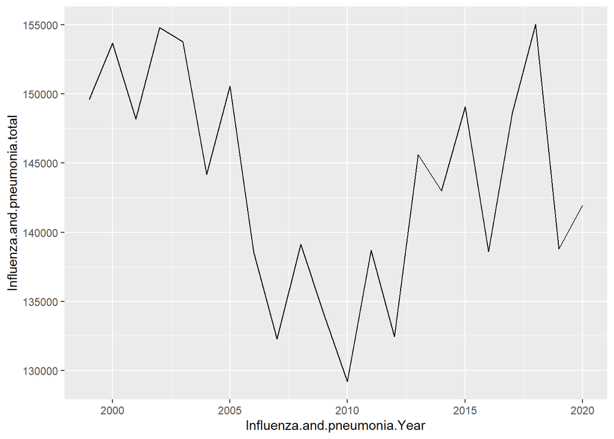

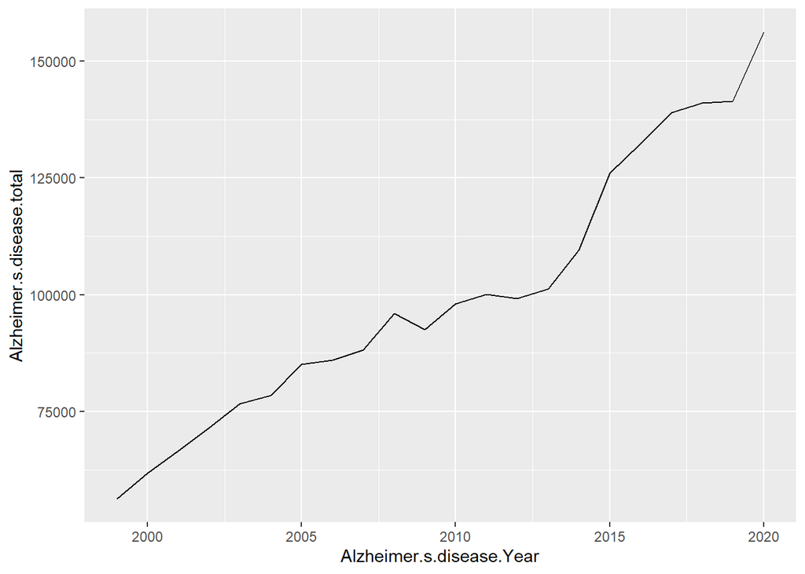

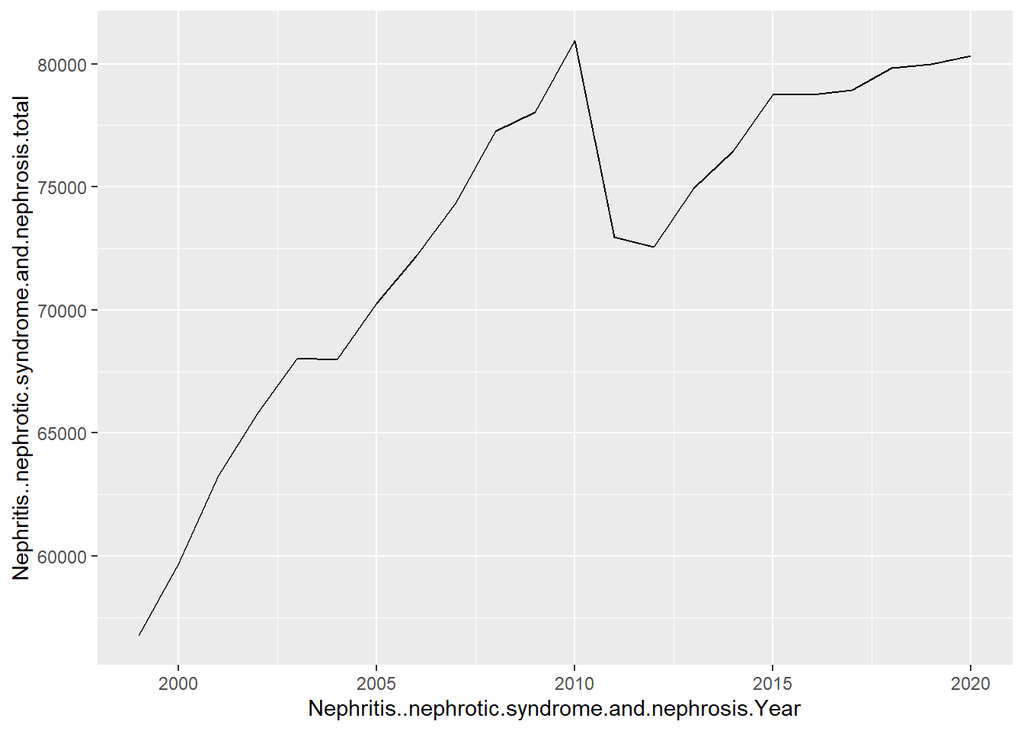

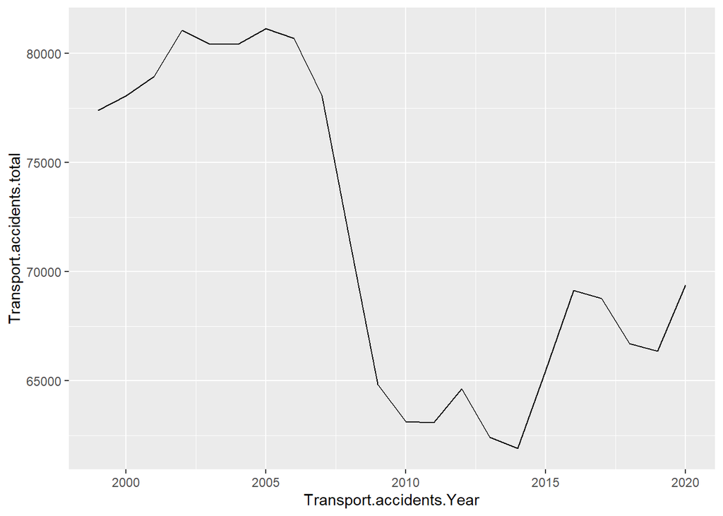

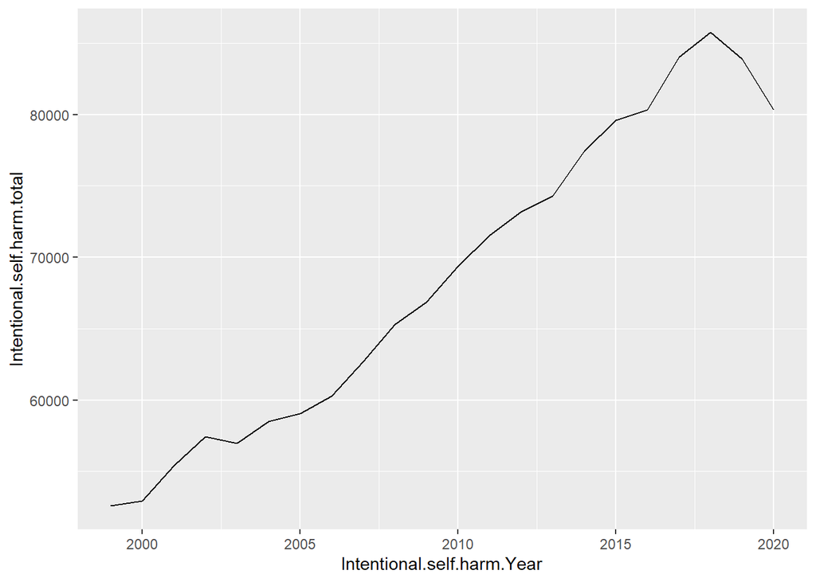

Diseases of heart have been dropping significantly until 2013 where they began to increase and spiked up in 2020. Influenza and Pneumonia oscillates from year to year, sometimes being severe one year, less severe the next, and severe again after that.

## 18.

Create a model that uses time to predict the number Of deaths from all causes (consider 1999 as t=O). Give the equation of your model and justify how you chose your model. What might be some limitations or cautions Of using this model to predict future death totals considering the sudden increase in deaths due to the onset of the COVID-19 pandemic?

```r
topDeaths = data %>% group_by(Year) %>% summarize(total = sum(Deaths))
topDeaths$Year = topDeaths$Year - 1999

lmodel <- lm(total~Year, data = topDeaths)
summary(lmodel)
```

```
##
## Call:
## lm(formula = total ~ Year, data = topDeaths)
##
## Residuals:
##     Min      1Q  Median      3Q     Max
## -204359 -147115  -28719   84200  716737
##
## Coefficients:
##             Estimate Std. Error t value Pr(>|t|)
## (Intercept)  3758368      86400  43.500   <2e-16 ***
## Year           15804       7043   2.244   0.0363 *
## ---
## Signif. codes:  0 '***' 0.001 '**' 0.01 '*' 0.05 '.' 0.1 ' ' 1
##
## Residual standard error: 209600 on 20 degrees of freedom
## Multiple R-squared:  0.2011, Adjusted R-squared:  0.1612
## F-statistic: 5.036 on 1 and 20 DF,  p-value: 0.03631
```

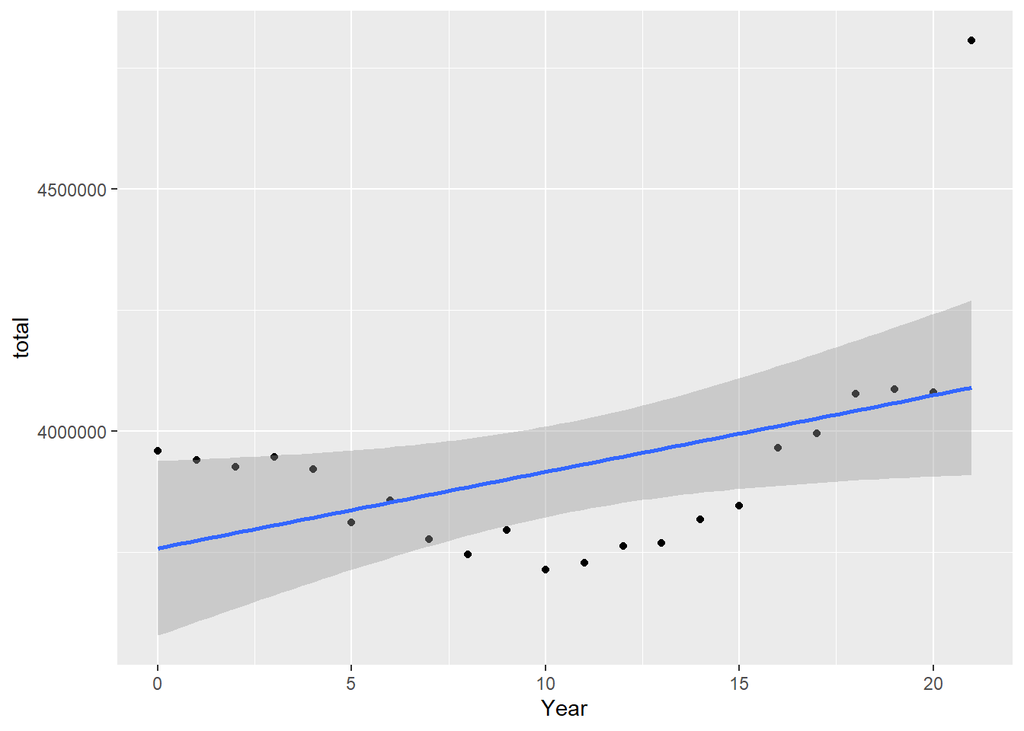

```r
ggplot(topDeaths, aes(Year, total)) +
  geom_point() +
  geom_smooth(method = lm, model = total~Year)
```

## 19.

Since Heart Disease continues to be a leading cause of death in the US, researchers want to predict the number of deaths from it in the future. Use the data to create a model that uses time to predict the number of Heart Disease deaths (consider 1999 as t=O). Give the equation of your model and justify how you chose your model.

```r
heartDeaths = data %>% group_by(Year) %>% filter(Cause == "Diseases of heart (I00-I09,I11,I13,I20-I51)") %>% summarize(total = sum(Deaths))
heartDeaths$Year = heartDeaths$Year - 1999

hmodel <- lm(total ~ Year + I(Year^2), data=heartDeaths)
summary(hmodel)
```

```
##
## Call:
## lm(formula = total ~ Year + I(Year^2), data = heartDeaths)
##
## Residuals:
##    Min     1Q Median     3Q    Max
## -31650 -14868    421   8172  38999
##
## Coefficients:
##              Estimate Std. Error t value Pr(>|t|)
## (Intercept) 1627089.1    11154.5  145.87  < 2e-16 ***
## Year         -58394.6     2461.1  -23.73 1.40e-15 ***
## I(Year^2)      1960.9      113.2   17.33 4.24e-13 ***
## ---
## Signif. codes:  0 '***' 0.001 '**' 0.01 '*' 0.05 '.' 0.1 ' ' 1
##
## Residual standard error: 19050 on 19 degrees of freedom
## Multiple R-squared:  0.9818, Adjusted R-squared:  0.9799
## F-statistic: 511.8 on 2 and 19 DF,  p-value: < 2.2e-16
```

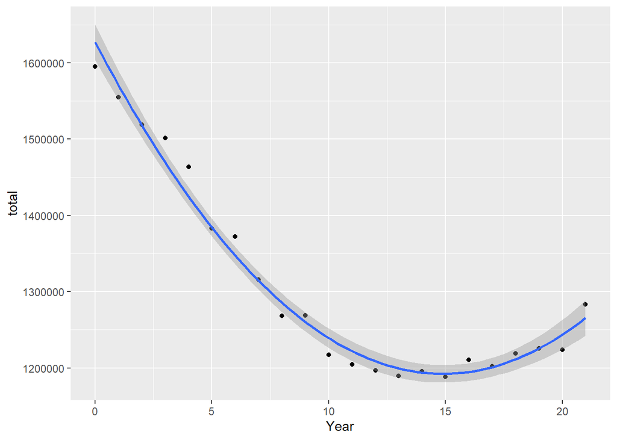

```r
ggplot(data = heartDeaths, aes(x=Year, y = total)) +
    geom_point() +
  geom_smooth(method = "lm", formula = y ~ x + I(x^2))
```

The equation of this model is total = a*x^2+bx+c. I chose a quadratic model because it provides a very accurate fit to the data with an R^2 of 0.9818.

## 20.

Using this model, predict the number Of deaths from heart disease in 2025.

```r
Year = c(25)
year = data.frame(Year)
predict.lm(hmodel, year)
```

```
##       1
## 1392786
```

# Part 4: Critical Thinking & Risk Analysis

## 21.

Using your model created in Question #18, if none of the proposed programs (suicide prevention, opiod, heart disease) are implemented, what is the predicted number Of US deaths in 2025?

```r
Year = c(25)
year = data.frame(Year)
predict.lm(lmodel, year)
```

```
##       1
## 4153474
```

## 22.

If the suicide prevention program is implemented effectively ONLY (ie, the opioid intervention and heart disease prevention programs are NOT implemented), what is the predicted number of US suicides in 2025?

```r
sDeaths = data %>% group_by(Year) %>% filter(Cause == "Intentional self-harm (suicide) (*U03,X60-X84,Y87.0)") %>% summarize(total = sum(Deaths))
sDeaths$Year = heartDeaths$Year - 1999

smodel <- lm(total~Year, data=sDeaths)
summary(smodel)
```

```
##
## Call:
## lm(formula = total ~ Year, data = sDeaths)
##
## Residuals:
##     Min      1Q  Median      3Q     Max
## -5762.9  -821.2   144.3  1311.3  3017.2
##
## Coefficients:
##              Estimate Std. Error t value Pr(>|t|)
## (Intercept) 3.389e+06  1.329e+05   25.50   <2e-16 ***
## Year        1.670e+03  6.684e+01   24.99   <2e-16 ***
## ---
## Signif. codes:  0 '***' 0.001 '**' 0.01 '*' 0.05 '.' 0.1 ' ' 1
##
## Residual standard error: 1989 on 20 degrees of freedom
## Multiple R-squared:  0.969,  Adjusted R-squared:  0.9674
## F-statistic: 624.4 on 1 and 20 DF,  p-value: < 2.2e-16
```

```r
Year = c(25)
year = data.frame(Year)
predict.lm(smodel, year) * 0.76
```

[output not shown]

## 23.

# Part 5: Recommendations

## 24.

The head of the think tank is able to fundraise up to $100,000,000 for program implementations and wishes to use that money to fund two Of the programs. If all monies must be spent in one year, which two programs would you recommend she choose? Why?

The two most influential programs would be Opioid and Heart Disease. Although they have a lower impact on % deaths per year, the total number of deaths in each category is significantly higher, thus making the smaller % still save more lives.

## 25.

From 1999 to 2009 heart disease was trending downward fairly steadily. The researchers want to see what would happen if we could get heart disease trending down again at the same rate as it was during these years. Project heart disease rates up to 2030 if they were to start trending downward at the 1999-2009 rate.

```r
deaths1999 = data %>% filter(Cause == "Diseases of heart (I00-I09,I11,I13,I20-I51)" & Year == "1999") %>% summarize(total = sum(Deaths))
deaths2009 = data %>% filter(Cause == "Diseases of heart (I00-I09,I11,I13,I20-I51)" & Year == "2009") %>% summarize(total = sum(Deaths))
decrease = (deaths1999-deaths2009)/(deaths1999) # percentage decrease in heart disease deaths from 1999-2009
deaths2020 = data %>% filter(Cause == "Diseases of heart (I00-I09,I11,I13,I20-I51)" & Year == "2020") %>% summarize(total = sum(Deaths))
pred = deaths2020*(1-decrease)
pred
```

```
##      total
## 1 979182.7
```

## 26.

The think tank wants to recommend piloting the suicide prevention program intervention in one state which state would each have the most impact and why? Does your recommendation target sheer numbers Of lives saved or the trend Of the state? Why? Explain your rationale and method.